# Introduction to Statistical Learning 2e - Chapter 03 - Linear Regression

Author

Farooq Mahmud

**Preamble**

```r
library(ISLR2)
library(tidyverse)
library(viridis)
library(glmtoolbox)

rounded <- function(n, digits = 2) {
  return(round(n, digits))
}

boston <- ISLR2::Boston
```

## Simple Linear Regression

**Fit a simple linear regression model, with `medv` as the response and `lstat` as the predictor.**

```r
model <- glm(medv ~ lstat, data = boston, family = "gaussian")
summary(model)
```

```
Call:
glm(formula = medv ~ lstat, family = "gaussian", data = boston)

Coefficients:
            Estimate Std. Error t value Pr(>|t|)
(Intercept) 34.55384    0.56263   61.41   <2e-16 ***
lstat       -0.95005    0.03873  -24.53   <2e-16 ***
---
Signif. codes:  0 '***' 0.001 '**' 0.01 '*' 0.05 '.' 0.1 ' ' 1

(Dispersion parameter for gaussian family taken to be 38.63568)

    Null deviance: 42716  on 505  degrees of freedom
Residual deviance: 19472  on 504  degrees of freedom
AIC: 3289

Number of Fisher Scoring iterations: 2
```

**Plot `medv` and `lstat` along with the regression line.**

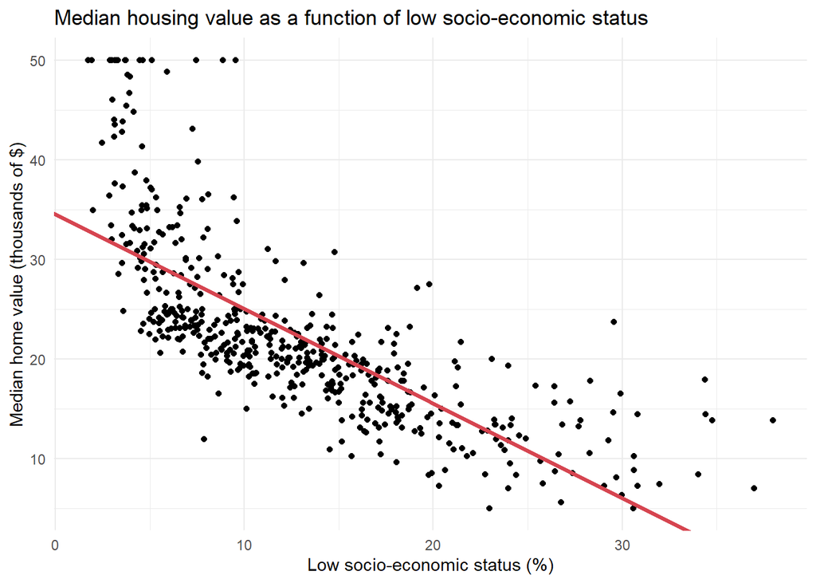

```r
boston |>
  ggplot(aes(x = lstat, y = medv)) +
  geom_point() +
  geom_abline(intercept = model$coefficients[1], slope = model$coefficients[2], color = "#D64550", linewidth = 1.2) +
  labs(
    title = "Median housing value as a function of low socio-economic status",
    x = "Low socio-economic status (%)",
    y = "Median home value (thousands of $)"
  ) +
  scale_color_viridis_c(option = "C", direction = -1) +
  theme_minimal()
```

## Multiple Linear Regression

**Fit a multiple linear regression model, with `medv` as the response and `lstat` and `age` as the predictors.

```r
model2 <- glm(medv ~ lstat + age, data = boston, family = "gaussian")
summary(model2)
```

```
Call:
glm(formula = medv ~ lstat + age, family = "gaussian", data = boston)

Coefficients:
            Estimate Std. Error t value Pr(>|t|)
(Intercept) 33.22276    0.73085  45.458  < 2e-16 ***
lstat       -1.03207    0.04819 -21.416  < 2e-16 ***
age          0.03454    0.01223   2.826  0.00491 **
---
Signif. codes:  0 '***' 0.001 '**' 0.01 '*' 0.05 '.' 0.1 ' ' 1

(Dispersion parameter for gaussian family taken to be 38.10761)

    Null deviance: 42716  on 505  degrees of freedom
Residual deviance: 19168  on 503  degrees of freedom
AIC: 3283

Number of Fisher Scoring iterations: 2
```

**Fit a multiple linear regression model, with `medv` as the response and the remaining variables as the predictors.

```r
model3 <- glm(medv ~ ., data = boston, family = "gaussian")
summary(model3)
```

```
Call:
glm(formula = medv ~ ., family = "gaussian", data = boston)

Coefficients:
              Estimate Std. Error t value Pr(>|t|)
(Intercept)  41.617270   4.936039   8.431 3.79e-16 ***
crim         -0.121389   0.033000  -3.678 0.000261 ***
zn            0.046963   0.013879   3.384 0.000772 ***
indus         0.013468   0.062145   0.217 0.828520
chas          2.839993   0.870007   3.264 0.001173 **
nox         -18.758022   3.851355  -4.870 1.50e-06 ***
rm            3.658119   0.420246   8.705  < 2e-16 ***
age           0.003611   0.013329   0.271 0.786595
dis          -1.490754   0.201623  -7.394 6.17e-13 ***
rad           0.289405   0.066908   4.325 1.84e-05 ***
tax          -0.012682   0.003801  -3.337 0.000912 ***
ptratio      -0.937533   0.132206  -7.091 4.63e-12 ***
lstat        -0.552019   0.050659 -10.897  < 2e-16 ***
---
Signif. codes:  0 '***' 0.001 '**' 0.01 '*' 0.05 '.' 0.1 ' ' 1

(Dispersion parameter for gaussian family taken to be 23.02113)

    Null deviance: 42716  on 505  degrees of freedom
Residual deviance: 11349  on 493  degrees of freedom
AIC: 3037.8

Number of Fisher Scoring iterations: 2
```

**Is this a significant regression line at $\alpha=0.05$?**

```r
model3_reduced <- glm(medv ~ 1, data = boston, family = "gaussian")
anova(model3_reduced, model3)
```

```
Analysis of Deviance Table

Model 1: medv ~ 1
Model 2: medv ~ crim + zn + indus + chas + nox + rm + age + dis + rad +
    tax + ptratio + lstat
  Resid. Df Resid. Dev Df Deviance      F    Pr(>F)
1       505      42716
2       493      11349 12    31367 113.54 < 2.2e-16 ***
---
Signif. codes:  0 '***' 0.001 '**' 0.01 '*' 0.05 '.' 0.1 ' ' 1
```

$H_0$: All slopes are zero. $H_1$: At least one slope is non-zero.

Since $p<\alpha$, there is sufficient evidence to suggest at least one slope is non-zero. Therefore, $H_0$ is rejected.

```r
model4 <- glm(medv ~ . - age - indus, data = boston, family = "gaussian")
summary(model4)
```

```
Call:
glm(formula = medv ~ . - age - indus, family = "gaussian", data = boston)

Coefficients:
              Estimate Std. Error t value Pr(>|t|)
(Intercept)  41.451747   4.903283   8.454 3.18e-16 ***
crim         -0.121665   0.032919  -3.696 0.000244 ***
zn            0.046191   0.013673   3.378 0.000787 ***
chas          2.871873   0.862591   3.329 0.000935 ***
nox         -18.262427   3.565247  -5.122 4.33e-07 ***
rm            3.672957   0.409127   8.978  < 2e-16 ***
dis          -1.515951   0.187675  -8.078 5.08e-15 ***
rad           0.283932   0.063945   4.440 1.11e-05 ***
tax          -0.012292   0.003407  -3.608 0.000340 ***
ptratio      -0.930961   0.130423  -7.138 3.39e-12 ***
lstat        -0.546509   0.047442 -11.519  < 2e-16 ***
---
Signif. codes:  0 '***' 0.001 '**' 0.01 '*' 0.05 '.' 0.1 ' ' 1

(Dispersion parameter for gaussian family taken to be 22.93371)

    Null deviance: 42716  on 505  degrees of freedom
Residual deviance: 11352  on 495  degrees of freedom
AIC: 3033.9

Number of Fisher Scoring iterations: 2
```

**Compute the predicted values using the prededing models. Add the predictions to the `boston` dataset.**

```r
boston <- boston |>
  mutate(medv_predicted_m1 = predict(model)) |>
  mutate(medv_predicted_m2 = predict(model2)) |>
  mutate(medv_predicted_m3 = predict(model3)) |>
  mutate(medv_predicted_m4 = predict(model4)) |>
  relocate(medv, .before = crim) |>
  relocate(medv_predicted_m1, .after = medv) |>
  relocate(medv_predicted_m2, .after = medv_predicted_m1) |>
  relocate(medv_predicted_m3, .after = medv_predicted_m2) |>
  relocate(medv_predicted_m4, .after = medv_predicted_m3)

boston |> select(1:5) |> head(3)
```

```
  medv medv_predicted_m1 medv_predicted_m2 medv_predicted_m3 medv_predicted_m4
1 24.0          29.82260          30.33535          30.03374          30.08701
2 21.6          25.87039          26.51520          25.05683          24.96464
3 34.7          30.72514          31.17418          30.60819          30.56344
```

**Compare the adjusted $R^2$ values for each model. What conclusions can be made?**

```r
models <- list(model, model2, model3, model4)
model_names <- c("m1", "m2", "m3", "m4")

r_squared_df <- data.frame(
  model = model_names,
  adj_r2 = sapply(models, adjR2)
)

r_squared_df
```

```
  model  adj_r2
1    m1 0.54324
2    m2 0.54948
3    m3 0.72784
4    m4 0.72887
```

Model #3 and #4 have better fits than Models #1 and #2. Model #4 has a better fit than Model #3 with two fewer variables.

**Is multicoliearality a problem with the preceding model?**

```r
library(car)
car::vif(model4)
```

```
    crim       zn     chas      nox       rm      dis      rad      tax
1.765478 2.239107 1.056997 3.758338 1.819577 3.438955 6.826385 7.258419
 ptratio    lstat
1.755565 2.527415
```

Most VIF values are below five, which suggests multicoliearality is not a problem. There appears to me some correlation between `rad` and `tax` and this can be verified using `cor()`:

```r
cor(boston$rad, boston$tax)
```

```
[1] 0.9102282
```

Let’s remove `tax` from the model since it has a higher $p$-value than `rad`:

```r
boston_orig <- ISLR2::Boston
model5 <- glm(medv ~ . - age - indus - tax, data = boston_orig, family = "gaussian")
summary(model5)
```

```
Call:
glm(formula = medv ~ . - age - indus - tax, family = "gaussian",
    data = boston_orig)

Coefficients:
             Estimate Std. Error t value Pr(>|t|)
(Intercept)  39.98405    4.94523   8.085 4.78e-15 ***
crim         -0.11854    0.03330  -3.559 0.000407 ***
zn            0.03658    0.01357   2.695 0.007279 **
chas          3.13944    0.86975   3.610 0.000338 ***
nox         -21.37566    3.50093  -6.106 2.07e-09 ***
rm            3.85056    0.41105   9.368  < 2e-16 ***
dis          -1.45079    0.18905  -7.674 8.92e-14 ***
rad           0.10457    0.04071   2.569 0.010495 *
ptratio      -1.00175    0.13049  -7.677 8.74e-14 ***
lstat        -0.55346    0.04797 -11.537  < 2e-16 ***
---
Signif. codes:  0 '***' 0.001 '**' 0.01 '*' 0.05 '.' 0.1 ' ' 1

(Dispersion parameter for gaussian family taken to be 23.48943)

    Null deviance: 42716  on 505  degrees of freedom
Residual deviance: 11651  on 496  degrees of freedom
AIC: 3045.1

Number of Fisher Scoring iterations: 2
```

```r
adjR2(model5)
```

```
[1] 0.7223
```

```r
car::vif(model5)
```

```
    crim       zn     chas      nox       rm      dis      rad  ptratio
1.764257 2.154051 1.049185 3.538215 1.793239 3.407113 2.701027 1.715836
   lstat
2.523246
```

The adjusted $R^2$ still indicates a decent fit with one less variable. The `vif()` output shows that multicoliearality is not a problem.

**Assess the assumptions on the linear model.**

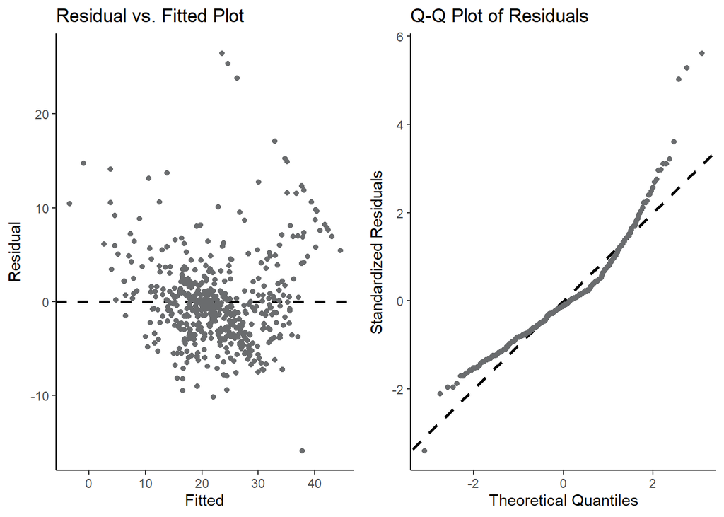

```r
library(classpackage)
anova_check(model5)
```

The Q-Q plot of the residulas don’t follow the diagonal line very well, indiciating the residuals do not follow a normal distribution. There is evidence for a non-linear fit.